# Assignment: ASSIGNMENT 3

# Name: Simek, Kathryn

# Date: 2020-09-13

1. What are the observational units in this study?

Answer: The observational units are the students’s scores.

2. Identify the variables mentioned in the narrative paragraph and determine which are categorical and quantitative?

Answer: The variables are: Section of course: Categorical; Course Grade: Categorical; Total Points Earned in Class: Quantitative; Number of students who earned each score total: Quantitative

3. Create one variable to hold a subset of your data set that contains only the Regular Section and one variable for the Sports Section.

```r
library(ggplot2)
theme_set(theme_minimal())

scores_df <- read.csv("data/scores.csv")

sports_df <- scores_df[scores_df$Section == "Sports",]
regular_df <- scores_df[scores_df$Section == "Regular",]
```

4. Use the Plot function to plot each Sections scores and the number of students achieving that score. Use additional Plot Arguments to label the graph and give each axis an appropriate label.

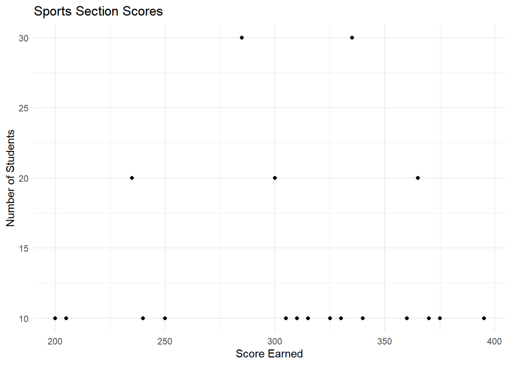

```r
ggplot(sports_df, aes(x=Score, y=Count)) + geom_point() +
  ggtitle("Sports Section Scores") + xlab("Score Earned") +
  ylab("Number of Students")
```

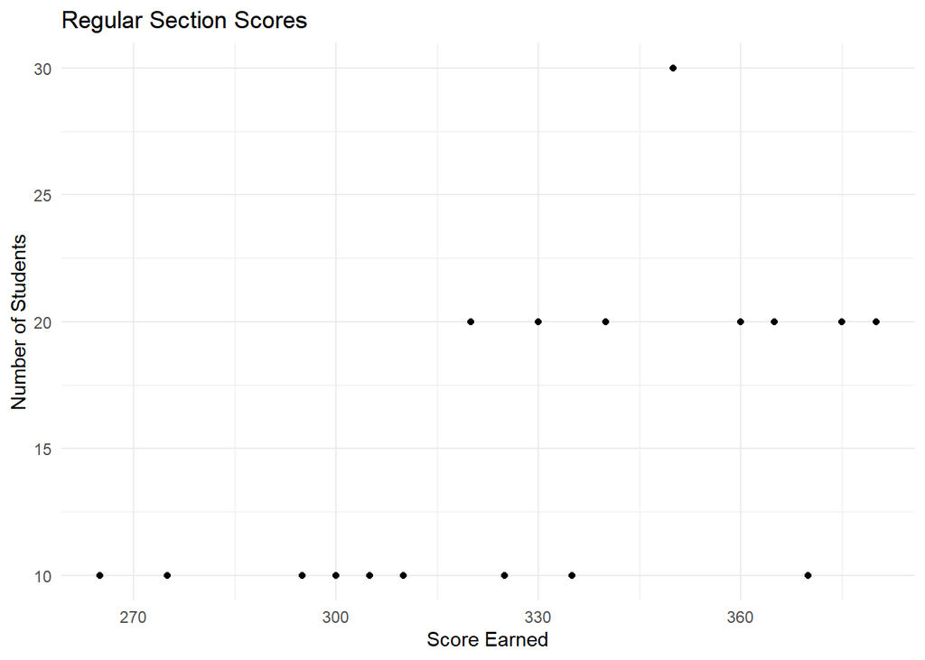

```r
ggplot(regular_df, aes(x=Score, y=Count)) + geom_point() +
  ggtitle("Regular Section Scores") + xlab("Score Earned") +
  ylab("Number of Students")
```

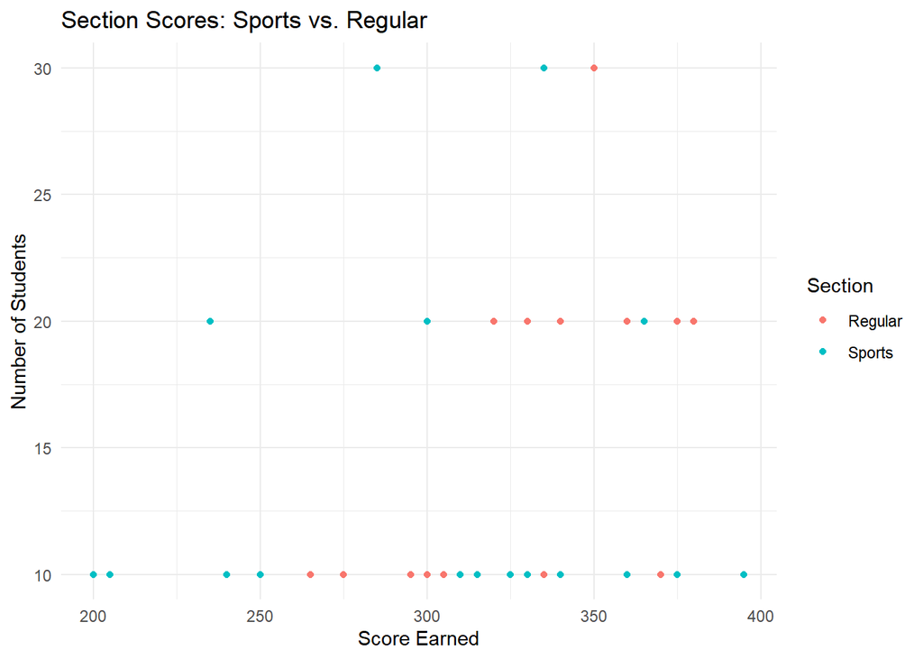

```r
ggplot(scores_df, aes(x=Score, y=Count, col=Section)) + geom_point() +
  xlab("Score Earned") +
  ylab("Number of Students") + ggtitle("Section Scores: Sports vs. Regular")
```

Once you have produced your Plots answer the following questions:

1. Comparing and contrasting the point distributions between the two section, looking at both tendency and consistency: Can you say that one section tended to score more points than the other? Justify and explain your answer.

Answer: Based on the skew and distribution of the scores, we can say that the “Regular” section tended to score more points than the “Sports” section. The plots show a more normal distribution for the regular section, while the sports section has a negative kurtosis. The scores for the regular section are more closely clustered together, with a higher value for the mean compared to the sports section with a wider distribution and variance in scores.

2. Did every student in one section score more points than every student in the other section? If not, explain what a statistical tendency means in this context.

Answer: Based on the wording of this question, I will say no, all the students in one section did not score higher than all the students in the other section. The scores overlap, so there are students in both sections that scored the same. The plots do show that the sports section had a wider range in scores than the regular section, however the students in the regular section had overall better average scores than those in the sports section.

3. What could be one additional variable that was not mentioned in the narrative that could be influencing the point distributions between the two sections?

Answer: I think there are two variables that could have a large impact on these distributions.One additional variable could be what the students’ majors were. This would help identify those students with a similar area of study to see if the course content was closely related and therefore those students scored higher. Another possible variable would be if the students had ever played sports. While it may see self explainatory that only those students with a sports background would choose that section, there could be instances where the student had to choose that section due to scheduling constraints. This would demonstrate whether the student had the knowledge to apply the sports examples sufficiently or if the sports nature of the course was a hinderance to their understanding of the topic.